# Face_Detection_&_Recognition_Raju_Hegde_ (1)

### Project Description:

In this hands-on project, the goal is to build a face identification model to recognize faces.

Data Description:

Aligned Face Dataset from Pinterest This dataset contains 10.770 images for 100 people. All images are taken from 'Pinterest' and aligned using dlib library.

Objective:

In this problem, we use a pre-trained model trained on Face recognition to recognize similar faces. Here, we are particularly interested in recognizing whether two given faces are of the same person or not.

Steps and Tasks:

● Load the dataset and create the metadata.

● Check some samples of metadata.

● Load the pre-trained model and weights.

● Generate Embedding vectors for each face in the dataset.

● Build distance metrics for identifying the distance between two given images.

● Use PCA for dimensionality reduction.

● Build SVM classifier to map each image to its right person.

● Predict using the SVM model.

```python
%tensorflow_version 2.x
```

```
TensorFlow is already loaded. Please restart the runtime to change versions.
```

```python
import tensorflow
tensorflow.__version__
```

```
'1.15.0'
```

```python
from google.colab import drive
drive.mount('/content/drive')
```

```python
import os
from zipfile import ZipFile
import numpy as np
import matplotlib.pyplot as plt
import cv2
from sklearn.preprocessing import LabelEncoder, StandardScaler
from sklearn.decomposition import PCA
from sklearn.svm import SVC

from tensorflow.keras.models import Sequential, Model
from tensorflow.keras.layers import Dense, Convolution2D, MaxPooling2D, Dropout, Flatten, Activation, ZeroPadding2D
```

Change current working directory to project folder (1 mark)

```python
os.chdir('/content/drive/My Drive/Deep Learning/Face Recognition/')
```

### Extract the zip file (5 Marks)

Extract Aligned Face Dataset from Pinterest.zip

```python
with ZipFile('Aligned Face Dataset from Pinterest.zip', 'r') as zip:
  zip.extractall()
```

Function to load images

Define a function to load the images from the extracted folder and map each image with person id

```python
class IdentityMetaData():
  def __init__(self, base, name, filename):
    self.base = base
    self.name = name
    self.filename = filename

  def __repr__(self):
    return self.image_path()

  def image_path(self):
    return os.path.join(self.base, self.filename, self.name)
```

```python
def load_metadata(path):
  metadata = []
  for folder in os.listdir(path):
    for image in os.listdir(os.path.join(path,folder)):
      extension = os.path.splitext(image)[1]
      if(extension == '.jpg' or extension == '.jpeg'):
        metadata.append(IdentityMetaData(base=path, name=image, filename=folder))
  return np.array(metadata)
```

```python
metadata = load_metadata('PINS')
```

## Define function to load image

Define a function to load image from the metadata

```python
def load_image(path):
  image = cv2.imread(path, cv2.IMREAD_COLOR)
  # OpenCV loads images with color channels
  # in BGR order. So we need to reverse them
  return image[...,::-1]
```

## Load a sample image (5 Marks)

Load one image using the function "load_image"

```
Shape of image is (295, 299, 3)
```

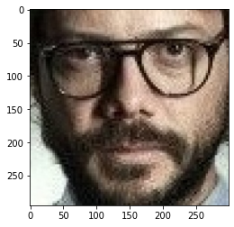

```python
i = np.random.randint(1,500)
img_meta= metadata[i]
path = str(img_meta)
image = load_image(path)
plt.imshow(image)
print(f'Shape of image is {image.shape}')
```

```python
image
```

[output not shown]

### VGG Face model

```python
def vgg_face():
  model = Sequential()
  model.add(ZeroPadding2D((1,1),input_shape=(224,224, 3)))
  model.add(Convolution2D(64, (3, 3), activation='relu'))
  model.add(ZeroPadding2D((1,1)))
  model.add(Convolution2D(64, (3, 3), activation='relu'))
  model.add(MaxPooling2D((2,2), strides=(2,2)))

  model.add(ZeroPadding2D((1,1)))
  model.add(Convolution2D(128, (3, 3), activation='relu'))
  model.add(ZeroPadding2D((1,1)))
  model.add(Convolution2D(128, (3, 3), activation='relu'))
  model.add(MaxPooling2D((2,2), strides=(2,2)))

  model.add(ZeroPadding2D((1,1)))
  model.add(Convolution2D(256, (3, 3), activation='relu'))
  model.add(ZeroPadding2D((1,1)))
  model.add(Convolution2D(256, (3, 3), activation='relu'))
  model.add(ZeroPadding2D((1,1)))
  model.add(Convolution2D(256, (3, 3), activation='relu'))
  model.add(MaxPooling2D((2,2), strides=(2,2)))

  model.add(ZeroPadding2D((1,1)))
  model.add(Convolution2D(512, (3, 3), activation='relu'))
  model.add(ZeroPadding2D((1,1)))
  model.add(Convolution2D(512, (3, 3), activation='relu'))
  model.add(ZeroPadding2D((1,1)))
  model.add(Convolution2D(512, (3, 3), activation='relu'))
  model.add(MaxPooling2D((2,2), strides=(2,2)))

  model.add(ZeroPadding2D((1,1)))
  model.add(Convolution2D(512, (3, 3), activation='relu'))
  model.add(ZeroPadding2D((1,1)))
  model.add(Convolution2D(512, (3, 3), activation='relu'))
  model.add(ZeroPadding2D((1,1)))
  model.add(Convolution2D(512, (3, 3), activation='relu'))
  model.add(MaxPooling2D((2,2), strides=(2,2)))

  model.add(Convolution2D(4096, (7, 7), activation='relu'))
  model.add(Dropout(0.5))
  model.add(Convolution2D(4096, (1, 1), activation='relu'))
  model.add(Dropout(0.5))
  model.add(Convolution2D(2622, (1, 1)))
  model.add(Flatten())
  model.add(Activation('softmax'))
  return model
```

## Load the model (5 Marks)

Load the model defined above

Then load the given weight file named "vgg_face_weights.h5"

```python
model = vgg_face()
```

```
WARNING:tensorflow:From /tensorflow-1.15.0/python3.6/tensorflow_core/python/ops/resource_variable_ops.py:1630: calling BaseResourceVariable.__init__ (from tensorflow.python.ops.resource_variable_ops) with constraint is deprecated and will be removed in a future version.
Instructions for updating:
If using Keras pass *_constraint arguments to layers.
```

```python
model.load_weights('vgg_face_weights.h5')
```

## Get vgg_face_descriptor

```python
from tensorflow.keras.models import Model
vgg_face_descriptor = Model(inputs = model.layers[0].input, outputs=model.layers[-2].output)
```

Generate embeddings for each image in the dataset

```python
image_path = metadata[4500].image_path()
image = load_image(image_path)
image = (image/255.).astype(np.float32)
image = cv2.resize(image, (224,224))
print(image.shape)

embeded_vector = vgg_face_descriptor.predict(np.expand_dims(image, axis=0))[0]
```

```
(224, 224, 3)
```

### Generate embeddings for all images (5 marks)

Write code to iterate through metadata and create embeddings for each image using vgg_face_descriptor.predict() and store in a list with name embeddings

If there is any error in reading any image in the dataset, fill the emebdding vector of that image with 2622-zeroes as the final embedding from the model is of length 2622.

```python
len(metadata)
```

```
10770
```

```python
# Creating this function as a hack to avoid the memory error. Running the loop for 10700 records to generate the embededvector
# was causing a memory error, and the entire notebook had to be rerun again.

def create_embeddings(from_i=0, to_i=0, metadata=metadata):
  embeddings = []
  for meta in metadata[from_i:to_i]:
    try:
      image = load_image(str(meta))
      image = (image/255.).astype(np.float32)
      image = cv2.resize(image, (224,224))
      embeded_vector = vgg_face_descriptor.predict(np.expand_dims(image, axis=0))[0]
    except:
      embeded_vector = np.zeros(2622)
    finally:
      embeddings.append(embeded_vector)
  return embeddings
```

```python
embeddings_1 = create_embeddings(from_i=0, to_i=4000)
```

```python
embeddings_2 = create_embeddings(from_i=4000, to_i=5000)
```

```python
embeddings_3 = create_embeddings(from_i=5000, to_i=7000)
```

```python
embeddings_4 = create_embeddings(from_i=7000, to_i=10770)
```

```python
embeddings = []
embeddings.extend(embeddings_1)
embeddings.extend(embeddings_2)
embeddings.extend(embeddings_3)
embeddings.extend(embeddings_4)
```

```python
len(embeddings)
```

```
10770
```

### Function to calculate distance between given 2 pairs of images.

Consider distance metric as "Squared L2 distance"

Squared l2 distance between 2 points (x1, y1) and (x2, y2) = (x1-x2)^2 + (y1-y2)^2

```python
def distance(emb1, emb2):
    return np.sum(np.square(emb1 - emb2))
```

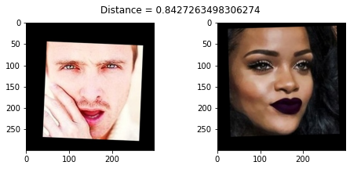

```python
import matplotlib.pyplot as plt

def show_pair(idx1, idx2):
    plt.figure(figsize=(8,3))
    plt.suptitle(f'Distance = {distance(embeddings[idx1], embeddings[idx2])}')
    plt.subplot(121)
    plt.imshow(load_image(metadata[idx1].image_path()))
    plt.subplot(122)
    plt.imshow(load_image(metadata[idx2].image_path()));

show_pair(2, 10000)
```

### Create train and test sets (5 marks)

Create X_train, X_test and y_train, y_test

Use train_idx to seperate out training features and labels

Use test_idx to seperate out testing features and labels

```python
train_idx = np.arange(metadata.shape[0]) % 9 != 0
test_idx = np.arange(metadata.shape[0]) % 9 == 0
```

```python
X_train, X_test = np.array(embeddings)[train_idx], np.array(embeddings)[test_idx]
```

```python
y_train, y_test = [obj.filename for obj in metadata[train_idx]] , [obj.filename for obj in metadata[test_idx]]
```

### Encode the Labels (5 marks)

Encode the targets

Use LabelEncoder

```python
le = LabelEncoder()
y_train = le.fit_transform(y_train)
y_test = le.transform(y_test)
```

### Standardize the feature values (5 marks)

Scale the features using StandardScaler

```python
scaler = StandardScaler()
X_train_scaled = scaler.fit_transform(X_train)
X_test_scaled = scaler.transform(X_test)
```

### Reduce dimensions using PCA (5 Marks)

Reduce feature dimensions using Principal Component Analysis

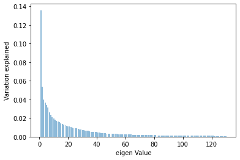

```python
pca = PCA(n_components=130)
pca.fit(X_train_scaled)

plt.bar(list(range(1,131)),pca.explained_variance_ratio_,alpha=0.5, align='center')
plt.ylabel('Variation explained')
plt.xlabel('eigen Value')
plt.show()
```

```python
X_pca_train = pca.transform(X_train_scaled)
X_pca_test = pca.transform(X_test_scaled)
```

### Build a Classifier (3 marks)

Use SVM Classifier to predict the person in the given image

```python
classifier = SVC(kernel='rbf')
```

```python
classifier.fit(X_pca_train, y_train)
```

```
SVC(C=1.0, break_ties=False, cache_size=200, class_weight=None, coef0=0.0,
    decision_function_shape='ovr', degree=3, gamma='scale', kernel='rbf',
    max_iter=-1, probability=False, random_state=None, shrinking=True,
    tol=0.001, verbose=False)
```

```python
y_pred = classifier.predict(X_pca_test)
```

```
(224, 224, 3)
```

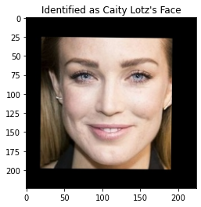

```python
import warnings
warnings.filterwarnings('ignore')

example_idx = np.random.randint(0,1197)

example_image = load_image(metadata[test_idx][example_idx].image_path())
example_image = (example_image/255.).astype(np.float32)
example_image = cv2.resize(example_image, (224,224))
print(example_image.shape)
embedding = vgg_face_descriptor.predict(np.expand_dims(example_image,axis=0))[0]
embedding_scaled = scaler.transform(embedding.reshape(1,-1))
example_prediction = classifier.predict(pca.transform(embedding_scaled))
example_identity = le.inverse_transform(example_prediction)[0].split('_')[-1]

plt.imshow(example_image)
plt.title(f"Identified as {example_identity}'s Face");
```